# InPreD_README

Jaime Abraham Castro-Mondragon & Jean-Marc Costanzi

Last update: 2026-11-27

## 1 Introduction

This document explains how to run the *InPreD* pipeline to detect small variants, CNAs, gene fusions and other mutations from an *Illumina TS0500* panel. Every week we sequence a batch of max 8 samples (hereafter referred as *sequencing run*), with its corresponding unique run ID (*RUN_ID*).

As the *MolPat* group at *Ahus* is gradually taking charge of the *InPreD* project. In the upcoming months the sequencing is done by *OUS*, they will send us the sequencing results of *Ahus* samples and we (*Ahus*) will do the postprocessing, QC and report generation.

## 2 Connect to the TSD and UiO Virtual Machines

### 2.1 TSD (Tjenester for Sensitive Data)

- In your browser, open the [View TSD Portal](https://view.tsd.usit.no/portal/webclient/#/home) website. Log in with your *username* and *2FA* first, then VMWare will ask your *password* (Figure 1).

[figure not shown]

**Figure 1.** Log in in the VMWare Horizon portal

- Click on the **p1150-rhel8-01-pool** icon, this will open the Linux VM (Figure 2). The other icon (*p1150-win02-pool*) will open the Windows VM.

[figure not shown]

**Figure 2.** Available VMs. Left: Linux, Right: Windows

### 2.2 UiO machine (Hypathia)

- In your browser, open the [View UiO Portal - Hypathia](https://view.uio.no/portal/webclient/#/launchitems) website. Log in with your *username* and your *UiO user password* (Figure 3).

[figure not shown]

**Figure 3.** Log in in the VMWare Horizon portal

- Click on the **UiO Linux Desktop** icon, this will open the Linux VM (Figure 3). The other icon (*Kontor Fullsjerm*) will open the Windows VM.

## 3 Import Samplesheets to TSD

Before launching the pipeline, we must generate the *SampleSheet* and *PRONTO* metadata from the [View UiO Portal - Hypathia](https://view.uio.no/portal/webclient/#/home), these files must be transfered to *TSD*.

Once in *TSD*, these files must be located at specific folder for the *TSO500* results and the *SampleSheet* must be transfered to *OUS* via an *OUS-Ahus* shared folder in *TSD* (see later).

### 3.1 Generate *SampleSheet* and *PRONTO* metadata

In previous versions, these steps were manual, but now we have an automated way to create these tables.

Both *SampleSheet* and *PRONTO* metadata content is found in the following file: `hypathia.uio.no/Ih-med-klinmed-ahus-inpred/TS0500/Samples_YYYY_wW.xlsx` (where *YYYY* = Year and *wWW* = week. Example: *w22* for week 22; see Figure 4 and 5).

[figure not shown]

**Figure 4.** Access the Hypathia server thorugh UiO View Portal

[figure not shown]

**Figure 5.** Original SampleSheet in View UiO portal

Follow the instructions below to automatically generate these tables.

- In your browser, open the [View UiO Portal - Hypathia](https://view.uio.no/portal/webclient/#/launchitems) website. Log in with your *username* and your *UiO user password* and click on the **UiO Linux Desktop** icon (see Figure 3).
- Go to the folder `\\platon.uio.no\med-klinmed-u2\jamondra\JACM/Ahus_InPreD_toolkit`, this is a copy of the [github repository Ahus_InPreD_toolkit](https://github.com/jaimicore/Ahus_InPreD_toolkit).
- Open the file `commands.txt` and manually update the following variables:
  - `WEEK` : set it to the current week in the format ‘wW’, where ‘W’ is the week number. Example for week 6 = w6.
  - `YYMMDD` : the date when sequencing started. Example: 260209.
- Launch the scripts (Running time ~2-3 minutes)

```bash
bash commands.txt
```

- Go to the results folder : `\\platon.uio.no\med-klinmed-u2\jamondra\JACM/Ahus_InPreD_toolkit/results/`, and go to the week you set on `commands.txt`, you will se the following files (Figure 6):
  - `coordinator_table_wW.csv` : contains clinical metadata and doctor contact and other information (sensitive)
  - `PRONTO_metadata_YYMMDD.txt` : patient metadata (age, year of diagnosis, cancer type, hospital) (sensitive)
  - `SampleSheet_ YYMMDD_info.csv` : sample ID and tumor content (not sensitive)

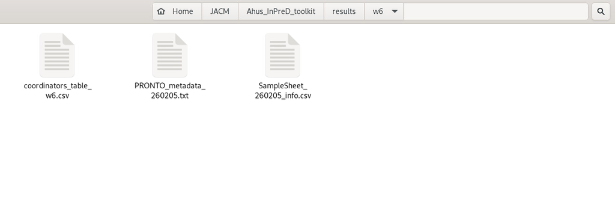

**Figure 6.** File produced after running `bash commands.txt` in the Toolkit InPreD folder.

- Switch to the Windows machine (*Kontor Fullsjerm*, see Figure 3). We will continue with the file transfer in this machine.
- Copy the `coordinator_table_wW.csv` to the following folder: `hypathia.uio.no/Ih-med-klinmed-ahus-inpred/IMPRESS/Coordinator_tables_from_script/2026`

> **⚠️ Important: report missing Tumor content**. In case any value in the *Tumor content* column is missing, report it with the responsible of this week’s sequencing.
- **PRONTO metadata**:
  - **Encrypt this file in *7z* format.** *Right click* on the file and select the *7-zip* option, select the *Leff til arkiv* option (Figure 7). This will open a window, write and repeat your encryption password in the *Angi passord* and *Bekreft passord* text boxes (Figure 8). Do not modify the other parameters.

[figure not shown]

**Figure 7.** Right click on the PRONTO metadata file to display encryption options

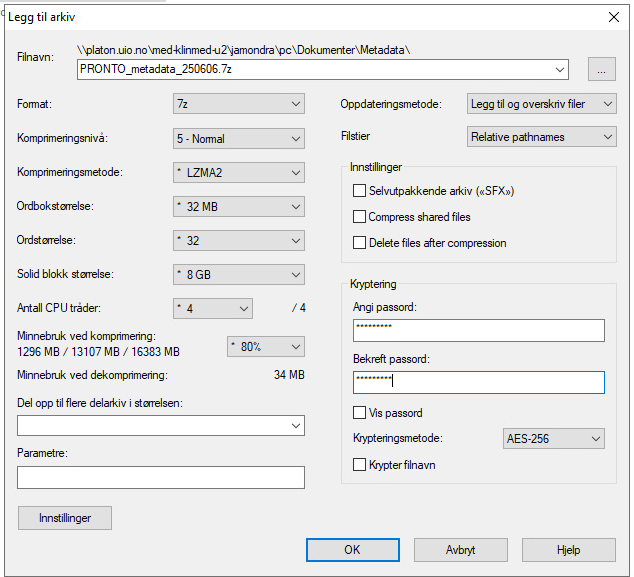

**Figure 8.** Write and repeat your encryption password

- **NOTE:** both *SampleSheet* and *PRONTO* metadata file **must** have the exact same date *YYMMDD*.

### 3.2 Import *SampleSheet* and *PRONTO* metadata (Uio View -> TSD)

- **NOTE**: the TSD import must be done through the *UiO View portal* only, never through a personal computer.
- Open *Chrome* or any internet browser.
- Go to the *TSD / Data Portal* and click on *Import Files* button (Figure 7).
- Log in with your *username*, *2F2 one time code*. and *password*.
- Upload the `SampleSheet_YYMMDD.csv` and `PRONTO_metadata_YYMMDD.7z` files. Verify both files are listed and checked, and click on the *import button* (Figure 8).
- **NOTE**: only import the encrypted *PRONTO metadata (.7z)* file, never the *.txt (non-encrypted)* file.

[figure not shown]

**Figure 7.** Import Files in TSD Data Portal

[figure not shown]

**Figure 8.** Verify SampleSheet and encrypted PRONTO metadata are listed and checked. Then click on the import button

- Open the [View TSD Portal](https://view.tsd.usit.no/portal/webclient/#/home) with the *Windows VM*.
- Verify that `SampleSheet_YYMMDD.csv` and `PRONTO_metadata_YYMMDD.7z` files are in the *file-import* folder (Figure 9): **`file-import/p1150-member-group/`**.
- Right click on the `PRONTO_metadata_YYMMDD.7z` file, select the *7-zip* option and *Pakk ut …* (Figure 10).
- Write the encryption password and click on *OK* (Figure 11).

[figure not shown]

**Figure 9.** In the import-files folder you will see the SampleSheet and the encrypted PRONTO metadata

[figure not shown]

**Figure 10.** Right click on the .7z file to show the decryption options.

[figure not shown]

**Figure 11.** Write the decryption password

## 4 Prepare pipeline

Before launching the pipeline we must verify if there is enough space in the disk and the size of the sequencing data.

### 4.1 Verify disk space availability

- **Disk space** : we need at least **300GB of free space**. If this is not the case, contact the persone responsible for the *p1150* project in TSD to release some space.

```bash
# Check disk space
df -h /ess/p1150
```

### 4.2 Connect to hpc (*Colossus*) server.

- **NOTE**: we must be connected to the *Colossus* server to launch the pipeline. Data manipulation can be done outside.

```bash
# Connect to hpc
ssh p1150-hpc-01
```

### 4.3 Pipeline run directory.

- **NOTE**: the pipeline must be launched from this folder.

```bash
cd  /ess/p1150/data/durable/software/pipeline/v004_sequencing_at_OUS_WIP
```

### 4.4 Set up global variables.

The following variables must be set up before launching the pipeline:

- Sequencing run ID = `RUN_ID`
- Input data type = `INPUT_DATA_TYPE`
- Sequencing run date = `RUN_DATE`
- Durable folder = `DURABLE`

```
RUN_ID=""
RUN_DATE="${RUN_ID%%_*}"
INPUT_DATA_TYPE="RAW"
DURABLE="/tsd/p1150/data/durable"
```

```bash
# Check ENV variables content
echo " "
echo $RUN_ID
echo $RUN_DATE
echo $INPUT_DATA_TYPE
echo $DURABLE
echo " "
```

### 4.5 Move *OUS*-shared *LocalApp* results

*OUS* (Oslo UniversitetsSykehus) will send the *LocalApp* results every Monday morning in the Ahus - OUS shared folder at `/ess/p1532sharedp1150/data/durable`

We will do the following steps:

- Move and rename the folder
- Rename the SampleSheet
- Create link

```bash
# Move and rename LocalApp folder
cp -R /ess/p1532sharedp1150/data/durable/${RUN_ID}_TSO_500* ${DURABLE}/TSO500_analyses/${RUN_ID}_TSO500_LocalApp_analysis_fromRAW
```

> **⚠️ Important**:as the *LocalApp* results take many GB in space, this step takes between 10-15 minutes to be completed.

```bash
# Verify the folder was moved correctly
ls ${DURABLE}/TSO500_analyses/${RUN_ID}_TSO500_LocalApp_analysis_fromRAW
```

```bash
# Rename LocalApp SampleSheet file
mv ${DURABLE}/TSO500_analyses/${RUN_ID}_TSO500_LocalApp_analysis_fromRAW/SampleSheet_${RUN_ID}_Ahus.csv ${DURABLE}/TSO500_analyses/${RUN_ID}_TSO500_LocalApp_analysis_fromRAW/SampleSheet_${RUN_ID}.csv
```

```bash
# Create link (that will be used when running PRONTO)
ln -s ${DURABLE}/TSO500_analyses/${RUN_ID}_TSO500_LocalApp_analysis_fromRAW ${DURABLE}/TSO500_analyses/${RUN_ID}_TSO500_LocalApp_analysis
```

### 4.6 Create decoy XML sequencing file

We need to set up a decoy XML file in *TSO500_sequences* folder, it will be used later by *TSOPPI* to display the sequencing metrics plots. The decoy XML file is a copy of the original XML file, but with all fields set to 0.

```bash
# Create the $RUN_ID folder in TSO500_sequences and copy the decoy XML file
mkdir -p ${DURABLE}/TSO500_sequences/${RUN_ID} ;

cp ${DURABLE}/TSO500_sequences/decoy_RunCompletionStatus.xml ${DURABLE}/TSO500_sequences/${RUN_ID}/RunCompletionStatus.xml ;
```

### 4.7 Prepare metadata

The sequences, the *PRONTO* metadata, and the *SampleSheet* for the current run ID are located in the `file-import` folder. They must be moved to the `TSO500_sequences`, `TSO500_pronto_metadata`, and `TSO500_SampleSheets` folders, respectively, before launching the analysis.

```bash
# Move SampleSheet metadata file
mv -i ${DURABLE}/file-import/p1150-member-group/SampleSheet_${RUN_DATE}_info.csv ${DURABLE}/TSO500_SampleSheets/SampleSheet_${RUN_DATE}_info.csv
```

```bash
# Move PRONTO file
mv -i ${DURABLE}/file-import/p1150-member-group/PRONTO_metadata_${RUN_DATE}.txt ${DURABLE}/TSO500_pronto_metadata/PRONTO_metadata_${RUN_DATE}.txt

mv -i ${DURABLE}/file-import/p1150-member-group/PRONTO_metadata_${RUN_DATE}.7z ${DURABLE}/TSO500_pronto_metadata/PRONTO_metadata_${RUN_DATE}.7z
```

### 4.8 Verify flags and source `config.sh`

The decryption/encryption related flags are used in *LocalApp*, due that this part is ran by *OUS* we set this variables as *F*.

```bash
# Default ';' but other separator (',', '-', '/') can be used
SEPARATOR=";"

DECRYPT_UNPACK_CHECKSUM="F"
REMOVE_ENCRYPTED_COMPRESSED_DATA="F"

MAKE_TSOPPI_CONFIG="T"
EXECUTE_TSOPPI_SCRIPTS="T"
```

- Use the following command to check those lines without opening the file in a text editor.

```bash
echo ' ';
echo ' ';

grep -e 'SEPARATOR='                        \
     -e 'DECRYPT_UNPACK_CHECKSUM='          \
     -e 'REMOVE_ENCRYPTED_COMPRESSED_DATA=' \
     -e 'MAKE_TSOPPI_CONFIG='               \
     -e 'EXECUTE_TSOPPI_SCRIPTS='           \
     config.sh

echo ' ';
echo ' ';
```

- Then source the `config` file

```bash
source config.sh ${RUN_ID}
```

### 4.9 Prepare folder structure

- Prepare the folder structure for a new run, this will create all folders to store results and logs.

```bash
bash 00_setup_folder_structure_for_new_run.sh ${RUN_ID}
```

### 4.10 Generate SampleSheet (00)

Running time: ~10 seconds

- We will generate a sample sheet with metadata for the current run ID.

```bash
bash 00_generate_TSO500_sample_sheet.sh ${RUN_ID} ${INPUT_DATA_TYPE} \
  &> ${SCRIPTS_AND_LOGS_FOLDER}/00_generate_TSO500_sample_sheet.log
```

```bash
more ${SCRIPTS_AND_LOGS_FOLDER}/00_generate_TSO500_sample_sheet.log
```

- Verify that the SampleSheet was correctly generated. If the separator is not the one indicated in the config file or if there is a missing column, you will see an error message in the `${SCRIPTS_AND_LOGS_FOLDER}/00_generate_TSO500_sample_sheet.log`.
  - If the Samplesheet was created you will see the following message in the last line of the logfile `Generating TSO500 samplesheet is succesfully finished.`
- Copy the logs and scripts for this sequencing run in the `${SCRIPTS_AND_LOGS_FOLDER}` folder.

```bash
cp -a 00_generate_TSO500_sample_sheet.sh ${SCRIPTS_AND_LOGS_FOLDER}
cp -a config.sh ${SCRIPTS_AND_LOGS_FOLDER}/00_config.sh
```

## 5 Launch TSO500 pipeline

- Now we are ready to launch the *TSO500* analysis pipeline. It has to be launched in many steps, and many of them require manual intervention.

### 5.1 Launch *LocalApp* analysis (01)

> **⚠️ Important**: this step is now outsourced to OUS, they will run this step and share with us the results. We just need to located the *LocalApp* results to the expected folder *TSO500_analyses* and continue the pipeline with *TSOPPI*.

### 5.2 Launch *TSOPPI* analysis

This analysis performs different analysis included in the [TSOPPI](https://tsoppi.readthedocs.io/en/latest/index.html) tool, such as:

- Quality control (QC) metrics for samples
- Fusion and splice variant output for RNA samples;
- Small variant output, copy number variant output (CNV) and microsatellite status (MS status) information for DNA samples.

#### 5.2.1 Create SampleSheet info *TSOPPI*

- Create the *TSOPPI* samplesheet.

```bash
cp ${SAMPLESHEETS_FOLDER}/${INFO_FILE_NAME} ${SAMPLESHEETS_FOLDER}/${INFO_FILE_NAME_TSOPPI}
```

#### 5.2.2 Adapt ALL_SEQUENCING_RUN_IDs global variable

- Update the file `$ALL_RUN_IDS` and add the new `$RUN_ID` in the second line. See the example below.

```bash
ALL_SEQUENCING_RUN_IDs=()
#  -->    HERE       <---        # Insert new SEQ_ID in this line #
ALL_SEQUENCING_RUN_IDs+=( "250522_AAAAAAAA_BBBB_CCCCCCCCCC" )
ALL_SEQUENCING_RUN_IDs+=( "250515_AAAAAAAA_BBBB_CCCCCCCCCC" )
```

```bash
ALL_RUN_IDS="${PIPELINE_FOLDER}/all_sequencing_runs.sh"

# Backup copy
cp "$ALL_RUN_IDS" "${ALL_RUN_IDS}.bk"

# Ensure RUN_ID is not empty
if [[ -z "$RUN_ID" ]]; then
    echo "Error: RUN_ID is empty"
    exit 1
fi

# Check if the RUN_ID is already present
if grep -qF "$RUN_ID" "$ALL_RUN_IDS"; then
    echo "RUN_ID already present in $ALL_RUN_IDS"
else
    # Insert RUN_ID after the initialization line
    TEMP_FILE=$(mktemp)
    insert_line='ALL_SEQUENCING_RUN_IDS+=( "'"$RUN_ID"'" )'

    awk -v line="$insert_line" '
        $0 ~ /^ALL_SEQUENCING_RUN_IDS[[:space:]]*=\(\)/ {
            print
            print line
            next
        }
        { print }
    ' "$ALL_RUN_IDS" > "$TEMP_FILE" && mv "$TEMP_FILE" "$ALL_RUN_IDS"

    # Verify insertion
    if grep -qF "$RUN_ID" "$ALL_RUN_IDS"; then
        echo "RUN_ID successfully added to $ALL_RUN_IDS"
    else
        echo "Failed to add RUN_ID to $ALL_RUN_IDS"
    fi
fi

chmod 755 $ALL_RUN_IDS
```

#### 5.2.3 Launch *TSOPPI* (02)

Running time: ~30 minutes (but may vary up to 1 hour)

```bash
bash 02_execute_tsoppi_and_archive_results.sh ${RUN_ID} \
  > ${SCRIPTS_AND_LOGS_FOLDER}/02_execute_tsoppi_and_archive_results.stdout \
  2> ${SCRIPTS_AND_LOGS_FOLDER}/02_execute_tsoppi_and_archive_results.stderr &
```

- Once this analysis is done, copy the logs and scripts for this sequencing run in the `${SCRIPTS_AND_LOGS_FOLDER}` folder.

```bash
cp -a 02_execute_tsoppi_and_archive_results.sh ${SCRIPTS_AND_LOGS_FOLDER}
cp -a config.sh ${SCRIPTS_AND_LOGS_FOLDER}/02_config.sh
```

### 5.3 Launch *ICNVA* analysis

[*ICNVA*](https://tsoppi.readthedocs.io/en/latest/ICNVA.html) runs two types of analysis on each input sample:

- Allele-specific copy number analysis performed by *PureCN* (LoH assessment).
- Normalized read coverage (NRC) profile plotting for selected genes (identify/confirm intra-genic duplications/losses).
- An in-house set of controls is utilized during both analyses.

#### 5.3.1 Select DNA tumour samples

- Adapt the `$SAMPLE_IDs` array to contain only DNA tumour samples, those ones containing **-D01-** in the second field in their sample ID.
- Be aware to adapt the variable according to the example below. Keep in mind the spacing, quotations and no separators.

```bash
SAMPLE_IDs=( "SAMPLE1" "SAMPLE_2" ... "SAMPLE_3" )
```

- **NOTE**: originally this step was done manually, now we added the code below to do it automatically.

```bash
# Get sorted sample IDs from SampleSheet
DNA_TUMOUR_SAMPLE_IDS=$(cut -d';' -f1 ${SAMPLESHEETS_FOLDER}/${INFO_FILE_NAME} | awk -F'-' '$2 ~ /D0[[:digit:]]+/' | sort)
#DNA_TUMOUR_SAMPLE_IDS=$(cut -d',' -f1 samples.txt | awk -F'-' 'tolower($2) == "d01"') # Case insensitive alternative

# Build array declaration string
ARRAY_STRING="SAMPLE_IDs=("
while IFS= read -r id; do
    ARRAY_STRING+=" \"$id\""
done <<< "$DNA_TUMOUR_SAMPLE_IDS"
ARRAY_STRING+=" )"

# Evaluate the string to create the array variable
eval "$ARRAY_STRING"
```

- Verify `SAMPLE_IDs` size and content.

```bash
# Optional: check the array content
declare -p SAMPLE_IDs

# Print array size and content in screen
echo ${#SAMPLE_IDs[@]}
printf "%s\n" "${SAMPLE_IDs[@]}"
```

#### 5.3.2 Launch *ICNVA* (025)

Running time: ~30 minutes

```bash
for SAMPLE_ID in ${SAMPLE_IDs[@]}
do
      echo "SAMPLE_ID=${SAMPLE_ID}"
      echo "RUN_ID=${RUN_ID}"

      bash 025_run_initial_icnva.sh \
          config.sh                 \
          ${RUN_ID}                 \
          ${SAMPLE_ID}              \
          > ${SCRIPTS_AND_LOGS_FOLDER}/025_run_initial_icnva_${SAMPLE_ID}_${RUN_ID}.stdout \
          2> ${SCRIPTS_AND_LOGS_FOLDER}/025_run_initial_icnva_${SAMPLE_ID}_${RUN_ID}.stderr &
done
```

- Once this analysis is done, copy the logs and scripts for this sequencing run in the `${SCRIPTS_AND_LOGS_FOLDER}` folder.

```bash
cp -a 025_run_initial_icnva.sh ${SCRIPTS_AND_LOGS_FOLDER}
cp -a config.sh ${SCRIPTS_AND_LOGS_FOLDER}/025_config.sh
```

### 5.4 Prepare predisposition tables

- Collect all predisposition tables in a single folder. These tables will be encrypted and exported with all the reports.

```bash
# Remove the content of RECENT_RUN folder
rm -rf ${DURABLE}/TSO500_export_for_interpretation/RECENT_RUN/*
```

```bash
# Create directory
WEEK=`date +"%U"`
PRED_TABLES="${DURABLE}/TSO500_export_for_interpretation/RECENT_RUN/predisposition_tables_w${WEEK}"
mkdir -p ${PRED_TABLES}

#
ls ${DURABLE}/TSO500_postprocessing/${RUN_ID}_TSOPPI_v0.3.2_main_2022_06_07/*/*_predisposition_gene_variant_table_tumor_RNA.tsv | while IFS= read -r file; do
  cp "$file" ${PRED_TABLES}/
done

ls ${PRED_TABLES}
```

### 5.5 Process QC variant tables (023)

- *TSOPPI* creates a `$RUN_ID/{sample_ID}/{sample_ID}_small_variants_table.tsv` with all the predicted variants and many (>30) annotation fields.
- To ease the QC process, we create an interactive html document with only the relevant columns and information needed for QC (including: patient and predicted sex, DNA-RNA concordance, tumor content (pathology vs predicted)).

> **⚠️ Important: to create the QC html file, you need to open a new terminal**
- Open a new terminal, you don’t need to connect to *colossus*.
- Run the following command to create the html document, this will produce the following files (one per sample ID in a given $RUN_ID): `$RUN_ID/{sample_ID}/{sample_ID}_QC_variants.html`
- Create the `$RUN_ID` variable
- Then run the container via the `run_QC_sif.sh` script.

```
RUN_ID=""
```

```bash
# Launch image from QC folder
cd $DURABLE/software/Ahus_InPreD_toolkit/QC

bash run_QC_sif.sh $RUN_ID
```

- Now we create a copy of all the files needed to be loaded in the *IGV* session: genome, annotations, manifest, BAM files, indexes and cytobands.

```bash
# Temporary file to save genomic files to load in IGV
IGV_FILES=${DURABLE}/TSO500_postprocessing/${RUN_ID}_TSOPPI_v0.3.2_main_2022_06_07/IGV
mkdir -p ${IGV_FILES}

# Create a copy of all the needed files to load in the IGV session
FUSVIZ_DIR=${DURABLE}/software/fusviz
cp ${FUSVIZ_DIR}/cytoBand.txt ${IGV_FILES}/cytoBand.txt      # Cytobands
cp ${FUSVIZ_DIR}/hg19.fasta ${IGV_FILES}/hg19.fasta          # Human genome sequence
cp ${FUSVIZ_DIR}/hg19.fasta.fai ${IGV_FILES}/hg19.fasta.fai  # Index


IGV_DIR=${DURABLE}/IGV/
IGV_REF_DIR=${IGV_DIR}/referece_data_TSO500_ruo_v.2.0.0.70
cp ${IGV_REF_DIR}/pepe_blacklist.bed.gz ${IGV_FILES}/pepe_blacklist.bed.gz                # BL regions
cp ${IGV_REF_DIR}/pepe_blacklist_sorted.bed.gz.tbi ${IGV_FILES}/pepe_blacklist.bed.gz.tbi # Index

cp ${IGV_REF_DIR}/TST500C_manifest_sorted.bed.gz ${IGV_FILES}/TST500C_manifest_sorted.bed.gz         # TSO500 regions
cp ${IGV_REF_DIR}/TST500C_manifest_sorted.bed.gz.tbi ${IGV_FILES}/TST500C_manifest_sorted.bed.gz.tbi # Index

cp ${IGV_REF_DIR}/hg19_ncbiRefSeq.txt ${IGV_FILES}/hg19_ncbiRefSeq.txt # Annotations

LOCALAPP_FOLDER=${DURABLE}/TSO500_analyses/${RUN_ID}_TSO500_LocalApp_analysis_fromRAW/Logs_Intermediates
LOCALAPP_DNA_FOLDER=${LOCALAPP_FOLDER}/StitchedRealigned
LOCALAPP_RNA_FOLDER=${LOCALAPP_FOLDER}/RnaMarkDuplicates

TUMOUR_SAMPLE_IDS=$(cut -d';' -f1 ${SAMPLESHEETS_FOLDER}/${INFO_FILE_NAME} | awk -F'-' '$2 ~ /D0[[:digit:]]+/' | sort)

# Build array declaration string
SAMPLES_ARRAY_STRING="SAMPLE_IDs=("
while IFS= read -r id; do
    SAMPLES_ARRAY_STRING+=" \"$id\""
done <<< "$TUMOUR_SAMPLE_IDS"
SAMPLES_ARRAY_STRING+=" )"

# Evaluate the string to create the array variable
eval "$SAMPLES_ARRAY_STRING"

for SAMPLE_ID in ${SAMPLE_IDs[@]}
do
      SAMPLE_FOLDER=${IGV_FILES}/${SAMPLE_ID} ;
      mkdir -p ${SAMPLE_FOLDER}

      echo "; Copying DNA BAM file + index : ${SAMPLE_ID}"
      cp ${LOCALAPP_DNA_FOLDER}/${SAMPLE_ID}/${SAMPLE_ID}.bam ${SAMPLE_FOLDER}/${SAMPLE_ID}.bam         # DNA BAM
      cp ${LOCALAPP_DNA_FOLDER}/${SAMPLE_ID}/${SAMPLE_ID}.bam.bai ${SAMPLE_FOLDER}/${SAMPLE_ID}.bam.bai # Index

      SAMPLE_ID_RNA="${SAMPLE_ID//-D01-/-R03-}"
      echo "; Copying RNA BAM file + index : ${SAMPLE_ID}"
      cp ${LOCALAPP_RNA_FOLDER}/${SAMPLE_ID_RNA}/${SAMPLE_ID_RNA}.bam ${SAMPLE_FOLDER}/${SAMPLE_ID_RNA}.bam         # RNA BAM
      cp ${LOCALAPP_RNA_FOLDER}/${SAMPLE_ID_RNA}/${SAMPLE_ID_RNA}.bam.bai ${SAMPLE_FOLDER}/${SAMPLE_ID_RNA}.bam.bai # Index

done
```

```bash
# Launch image from QC folder
cd $DURABLE/software/Ahus_InPreD_toolkit/QC

bash update_for_QC.sh $RUN_ID

# Return to the pipeline folder
cd  /ess/p1150/data/durable/software/pipeline/v004_sequencing_at_OUS_WIP

# Remove copy of genomic files
rm -rf ${IGV_FILES}
```

### 5.6 Create Intersection reports

Run the following commands to generate an *HTML* document showing the biomarkers found in the small variant tables after QC.

```bash
# Launch image Intersection folder
cd $DURABLE/software/Ahus_InPreD_toolkit/Intersection

singularity run                                        \
-B /ess/p1150/data/durable/TSO500_postprocessing:/data \
-B $PWD:/app                                           \
-B bm_table:/bm_table                                  \
BM_intersection.sif                                    \
-j 1 --configfile config_sif.yaml                      \
--config run_id=${RUN_ID} --forceall                   ;

# Verify that the html report was created
ls $DURABLE/software/Ahus_InPreD_toolkit/Intersection/results/${RUN_ID}/Biomarkers_found_report.html

mv $DURABLE/software/Ahus_InPreD_toolkit/Intersection/results/${RUN_ID}/Biomarkers_found_report.html $DURABLE/software/Ahus_InPreD_toolkit/Intersection/results/${RUN_ID}/Biomarkers_found_report_${RUN_ID}.html
```

### 5.7 Generate reports

Once the list of mutations was filtered by the curators, we are ready to proceed and generate the reports using *PRONTO*.

#### 5.7.1 Update *PRONTO* metadata master table

```bash
# Save a copy of the metadata file.
cp -i ${DURABLE}/software/PRONTO/PRONTO-1.2.0/In/InPreD_PRONTO_metadata.txt ${DURABLE}/software/PRONTO/PRONTO-1.2.0/In/InPreD_PRONTO_metadata.txt.bk

# Update the PRONTO metadata master table
python3 ${SCRIPTS_FOLDER}/update_metadata.py                                             \
  --new_meta ${DURABLE}/TSO500_pronto_metadata/PRONTO_metadata_${RUN_DATE}.txt           \
  --master_meta ${DURABLE}/software/PRONTO/PRONTO-1.2.0/In/InPreD_PRONTO_metadata.txt.bk \
  --run_id ${RUN_ID}                                                                     \
  --o ${DURABLE}/software/PRONTO/PRONTO-1.2.0/In/InPreD_PRONTO_metadata.txt.new ;
```

```bash
mv -i ${DURABLE}/software/PRONTO/PRONTO-1.2.0/In/InPreD_PRONTO_metadata.txt.new ${DURABLE}/software/PRONTO/PRONTO-1.2.0/In/InPreD_PRONTO_metadata.txt
```

#### 5.7.2 Generate reports with PRONTO (03)

- Remove the content of the `RECENT_RUN` folder.
- Launch the command to generate the *PRONTO* reports.

Running time: ~3-5 minutes per sample.

```bash
for SAMPLE_ID in ${SAMPLE_IDs[@]}
do
      echo "SAMPLE_ID=${SAMPLE_ID}"

      bash 03_generate_and_archive_pronto_report_collect_data_for_export.sh ${RUN_ID} ${SAMPLE_ID} ${SCRIPTS_AND_LOGS_FOLDER}/02_used_scripts/config_${RUN_ID}.sh \
          > ${SCRIPTS_AND_LOGS_FOLDER}/03_generate_and_archive_pronto_v${PRONTO_VERSION}_report_collect_data_for_export_${SAMPLE_ID}_${RUN_ID}.stdout             \
          2> ${SCRIPTS_AND_LOGS_FOLDER}/03_generate_and_archive_pronto_v${PRONTO_VERSION}_report_collect_data_for_export_${SAMPLE_ID}_${RUN_ID}.stderr

done
```

- Once this analysis is done, copy the logs and scripts for this sequencing run in the `${SCRIPTS_AND_LOGS_FOLDER}` folder.

```bash
cp -a 03_generate_and_archive_pronto_report_collect_data_for_export.sh ${SCRIPTS_AND_LOGS_FOLDER}
cp -a config.sh ${SCRIPTS_AND_LOGS_FOLDER}/03_config.sh
```

## 6 Transfer Reports (in TSD) to InPreD/MMOX folder

- Good. Now the results are complete and it is time to export them to another machine ([View UiO portal](https://view.uio.no/portal/webclient/#/home)) where the interpretation team can access the reports. We need the *Windows VM* to encrypt and compress the folders in the *.7z* format.
- Here we show an example for the InPreD reports. We do exactly the same for *MMOX* samples, except the *.7z* file is located at the *MMOX* folder (instead of the *InPreD* folder, both folders are located in the same path).

### 6.1 Encrypt folder with reports

- Switch to the Windows VM (*p1150-win02-pool*, Figure 12). The credential to log in are the same for *Ubunutu* and *Windows* VMs.
- Go to the `durable/TSO500_export_for_interpretation/RECENT_RUN/` folder. Verify that there is one folder per sample and one folder for the predisposition table (Figure 13).

[figure not shown]

**Figure 12.** Switch to the Windows VM

[figure not shown]

**Figure 13.** Verify RECENT_RUN content: one folder per sample and predisposition tables folder

[figure not shown]

**Figure 14.** Encrypt the RECENT_RUN folder

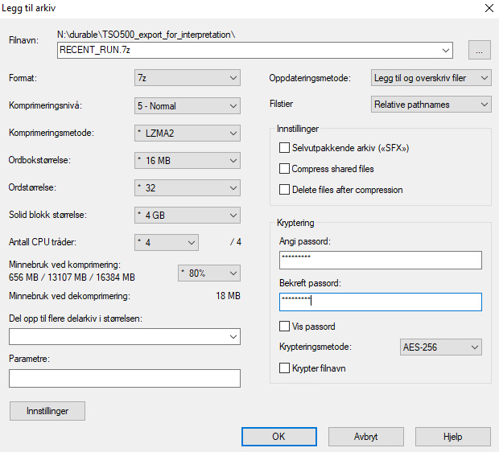

**Figure 15.** Write the password to encrypt the folder

[figure not shown]

**Figure 16.** Move the RECENT_RUN.7z file to the fire-export/ folder

### 6.2 Export Reports

- Log in into the [View UiO portal](https://view.uio.no/portal/webclient/#/home). You must write your *2FA* one time code and your password.
- Click on the *Kontor Fullskjerm* button. This will open a *Windows* machine (Figure 17).
- Open an internet browser and open the [TSD Data Portal](https://data.tsd.usit.no/). Click on the *Export Files* button (Figure 18). Log in with your username, password and *2FA* code.
- Click on the *RECENT_RUN.7z* file to download it. The file will be downloaded in the *Downloads* folder (Figure 19).
- Move the *RECENT_RUN.7z* file from *Downloads* folder to `hypathia.uio.no/Ih-med-klinmed-ahus-inpred/InPreD`.
- Right click on the *RECENT_RUN.7z* file, select the *7-Zip* tab and clcik on the *Pakk ut …* option (Figure 20).
- Write the decryption password (Figure 21).

> **⚠️ Important: Send an email to the local InPreD team** to tell them that the reports are ready in the *InPreD* folder. You can find a draft in the *Email Drafts* section below in this document.

[figure not shown]

**Figure 17.** Click on the Kontor Fullskjerm button. This will open a Windows machine

[figure not shown]

**Figure 18.** Open the TSD portal, click on the Export Data button

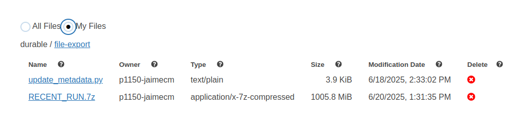

**Figure 19.** Click on the RECENT_RUN.7z file to start the download

[figure not shown]

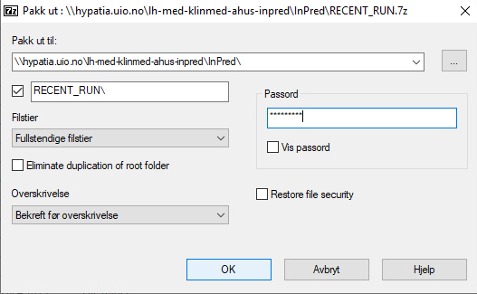

**Figure 21.** Write the decryption password and click on OK

## 7 QC variant tables

**NOTE:** *if you are new to QC first read the SOP document below or on hypatia.uio.no/Ih-med-klinmed-ahus-inpred/InPreD/TSO500_SOPs/Interpretation_and_QC/TSO500_QC_SOP.pdf*

Download SOP PDF

[figure not shown]

### 7.1 Check QC metrics

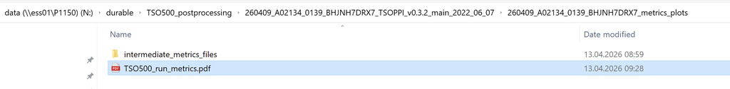

**Figure 22.** Open TSO500_run_metrics.pdf to verify the QC metrics for the run

- Check the entire QC metrics files and look of some samples or the entire run are overall bellow average in term of quality (use statistic from the previous runs to compare as well as the thresolds present in the figures). Pay a particular attention to:
  - **Median exon coverage**: should be at least 150bp
  - **Contamination assesment**: should be outside the red area
  - **Coverage mad**: should be below 0.22
  - **MSI sites**: should be at least 40 sites
  - **Mean family size**(how many time a DNA molecule has been sequenced)
  - **Read enchrichement**: should be arround 70%
  - **Chimeric reads**: should be less than 5%

### 7.2 Start IGV and load data

- Go to: `${DURABLE}/IGV/IGV_2.19.6` or `${DURABLE}/IGV/IGV_2.16.2` and double click on the bat file with your name, e.g.: `igv_port_60161_Jean-Marc.bat`

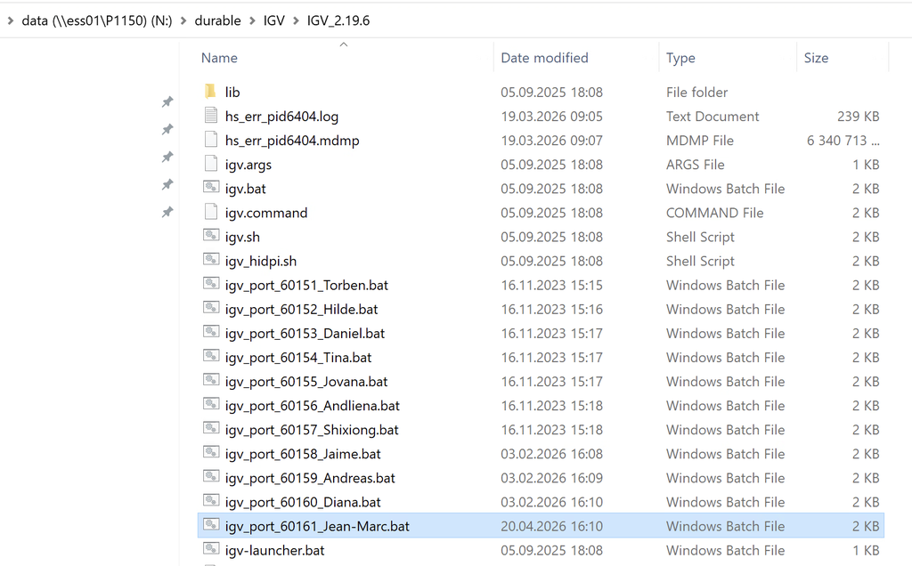

**Figure 23.** Open the IGV bat file to start IGV

- Click “ok” if some errors appears and once IGV is open click on: *Genomes* → *Load Genome from File* → select *hg19_TSO500_2.0.0.70.genome*

[figure not shown]

**Figure 24.** Load the reference genome

**NOTE:** The reference genome can take a bit of time to load.

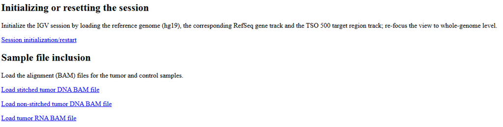

**Figure 25.** Load the BAM files into IGV

- IGV is now set and the BAM files are loaded for this sample.

**NOTE:** Always reinitialise the session when changing track.

- View as pair
- Sort alignement -> by base
- prefrence - alignement - show softclip based
- prefrence - alignement - show center line
- Always re initialise session when changing track or remove or adding track

### 7.3 QC using the html file

- Open the html file ending by **QC_variants.html** for the sample being QC eg: **IPA0123_D01-d01-A01_QC_variants.html**
- On top of the file there is a table which summarise the concordance between DNA and RNA for the sample being QC, the patient gender between the metadata and pureCN and the tumor content estimated by cytology and the three first pureCN solutions (use solution 1).

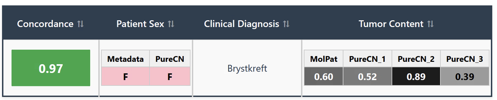

**Figure 26.** Summary table showing the concordance between DNA and RNA, patient gender, and tumor content

- You can use the filter to only display the variant of interest, e.g.: only the **include** variants in the column *Class_judgement* or only the **coding** variants.

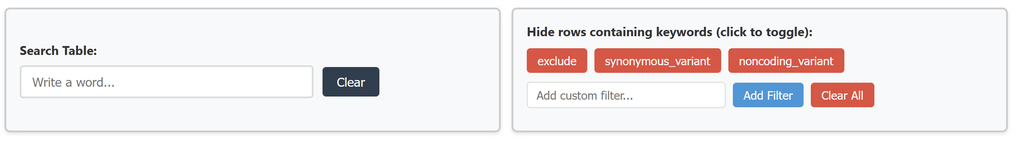

**Figure 27.** Use the filter to only display the variants of interest

- Once a variant is checked click on **OK** in the IGV_QC column.
- If a variant needs to be excluded click on **exclude** in the Class_judgement column and write the reason for the exclusion in the Class_judgement_comments column. **NOTE:** When leaving a comment in the *Class_judgement_comments* column, you can leave empty space and those will be replaced by underscore during export to tsv. Empty space are not supported by Pronto.

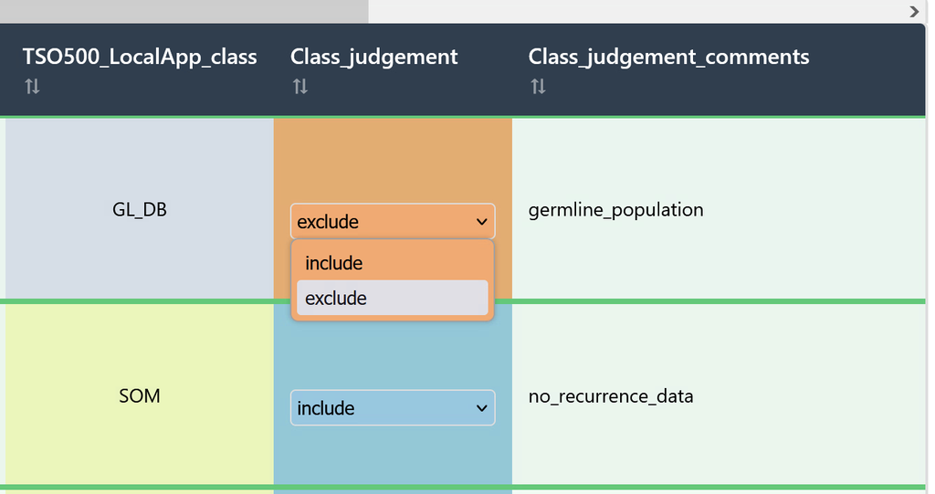

**Figure 28.** Change from exlude to include or the opposite and write the reason for exclusion in the Class_judgement_comments column

- When QC is finished and ready to be exported click on **Export Run QC to TSV**.
- The exported TSV file is now ready to be used for the next steps of the pipeline.